# Wine Dataset

- Abhilash Muniswamy Reddy

1. Intrduction
2. Data Import
   1. Import Libraries
   2. Change Directories
   3. Import Data
3. Data Cleaning
   1. Missing Values
   2. Bar plot of missing values
   3. Impute rows with missing values
   4. Outlier Detection and Removal
4. Data Exploration
   1. Heatmap of correlation between variables
   2. Distribution of variables
   3. Binning into low and high Quality
   4. Data exploration using different plots
      1. Violin plots
      2. Histograms
5. Class Balancing
6. Classification and Prediction
7. Quick Guide on Classification Metrics
8. Classification Models
   1. Function to obtain Confusion matrix & metrics
   2. Function to predict, score, create Confusion matrix & ROC curve
   3. Logistic Regression
   4. Decision Tree Classifier
   5. K-Nearest Neighbors
   6. Linear Discriminant Analysis
   7. Gaussian Naive Bayes
   8. Support Vector Machine
   9. Random Forest Classifier 10.Gradient Boosting Classifier Model
9. Comparison of different classifiers
10. References
11. Source

### Introduction

This dataset was downloaded from UCI Machine Learning Repository. The two datasets are related to red and white variants of the Portuguese "Vinho Verde" wine. For more details, consult: [Web Link] or the reference [Cortez et al., 2009]. Due to privacy and logistic issues, only physicochemical (inputs) and sensory (the output) variables are available (e.g. there is no data about grape types, wine brand, wine selling price, etc.).

These datasets can be viewed as classification or regression tasks. The classes are ordered and not balanced (e.g. there are many more normal wines than excellent or poor ones). Outlier detection algorithms could be used to detect the few excellent or poor wines.

In this project, the quality score is categorized into two bins of low quality and high quality wine. It aims to use different classifier models, compare and choose the best model to predict the quality of wine i.e. Low or High quality.

### Data Import

#### Import Libraries

```python
import os
import pandas as pd
import numpy as np
import re
import seaborn as sns
import matplotlib.pyplot as plt

import warnings
warnings.filterwarnings('ignore')
```

#### Changing Directories

```python
#print("Current Working Directory " , os.getcwd())
path = "D:\R\data"
os.chdir(path)
print("\nCurrent Working Directory " , os.getcwd())
```

```
Current Working Directory  D:\R\data
```

#### Import Data

```python
wine = pd.read_csv("winequalityN.csv")
wine.head()
#print("\nColumn names:", *wine.columns, sep='\n')
```

|  | type | fixed acidity | volatile acidity | citric acid | residual sugar | chlorides | free sulfur dioxide | total sulfur dioxide | density | pH | sulphates | alcohol | quality |
| --- | --- | --- | --- | --- | --- | --- | --- | --- | --- | --- | --- | --- | --- |
| 0 | white | 7.0 | 0.27 | 0.36 | 20.7 | 0.045 | 45.0 | 170.0 | 1.0010 | 3.00 | 0.45 | 8.8 | 6 |
| 1 | white | 6.3 | 0.30 | 0.34 | 1.6 | 0.049 | 14.0 | 132.0 | 0.9940 | 3.30 | 0.49 | 9.5 | 6 |
| 2 | white | 8.1 | 0.28 | 0.40 | 6.9 | 0.050 | 30.0 | 97.0 | 0.9951 | 3.26 | 0.44 | 10.1 | 6 |
| 3 | white | 7.2 | 0.23 | 0.32 | 8.5 | 0.058 | 47.0 | 186.0 | 0.9956 | 3.19 | 0.40 | 9.9 | 6 |
| 4 | white | 7.2 | 0.23 | 0.32 | 8.5 | 0.058 | 47.0 | 186.0 | 0.9956 | 3.19 | 0.40 | 9.9 | 6 |

### Data Cleaning

#### Missing Values

```python
Sum = wine.isnull().sum()
Percentage = ( wine.isnull().sum()/wine.isnull().count())
missing_val_tab = pd.concat([Sum,Percentage], axis =1, keys= ['Sum', 'Percentage'])
missing_val_tab = missing_val_tab.sort_values("Sum",ascending = False)

#Columns with Missing Values
fill_list = missing_val_tab[missing_val_tab['Sum']>0].index

#Reset & Rename index of new dataframe
missing_val_tab = missing_val_tab.reset_index()
missing_val_tab = missing_val_tab.rename(columns={"index":"Columns"})
missing_val_tab
```

|  | Columns | Sum | Percentage |
| --- | --- | --- | --- |
| 0 | fixed acidity | 10 | 0.001539 |
| 1 | pH | 9 | 0.001385 |
| 2 | volatile acidity | 8 | 0.001231 |
| 3 | sulphates | 4 | 0.000616 |
| 4 | citric acid | 3 | 0.000462 |
| 5 | residual sugar | 2 | 0.000308 |
| 6 | chlorides | 2 | 0.000308 |
| 7 | type | 0 | 0.000000 |
| 8 | free sulfur dioxide | 0 | 0.000000 |
| 9 | total sulfur dioxide | 0 | 0.000000 |
| 10 | density | 0 | 0.000000 |
| 11 | alcohol | 0 | 0.000000 |
| 12 | quality | 0 | 0.000000 |

#### Bar plot of Missing Values

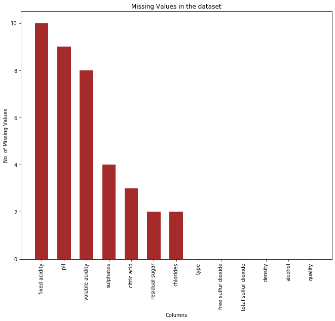

```python
#Bar plot using Matplotlib
fig = plt.figure(figsize = (11, 9))
plt.bar(missing_val_tab.Columns, missing_val_tab.Sum, color ='brown',
        width = 0.6)
plt.xticks(rotation= 90)
plt.xlabel("Columns")
plt.ylabel("No. of Missing Values")
plt.title("Missing Values in the dataset")
plt.show()
```

#### Impute Rows with Missing values

```python
wine_mean = wine.mean()
wine_med = wine.median()
pd.concat([wine_mean,wine_med], axis =1, keys= ['Mean', 'Median'])
```

|  | Mean | Median |
| --- | --- | --- |
| fixed acidity | 7.216579 | 7.00000 |
| volatile acidity | 0.339691 | 0.29000 |
| citric acid | 0.318722 | 0.31000 |
| residual sugar | 5.444326 | 3.00000 |
| chlorides | 0.056042 | 0.04700 |
| free sulfur dioxide | 30.525319 | 29.00000 |
| total sulfur dioxide | 115.744574 | 118.00000 |
| density | 0.994697 | 0.99489 |
| pH | 3.218395 | 3.21000 |
| sulphates | 0.531215 | 0.51000 |
| alcohol | 10.491801 | 10.30000 |
| quality | 5.818378 | 6.00000 |

Imputing using median as mean values might be skewed.

```python
wine_clean = wine.copy()

for col in fill_list:
    wine_clean.loc[:, col].fillna(wine_clean.loc[:, col].median(), inplace=True)

wine_clean.isnull().sum()
```

```
type                    0
fixed acidity           0
volatile acidity        0
citric acid             0
residual sugar          0
chlorides               0
free sulfur dioxide     0
total sulfur dioxide    0
density                 0
pH                      0
sulphates               0
alcohol                 0
quality                 0
dtype: int64
```

#### Outlier Detection and Removal

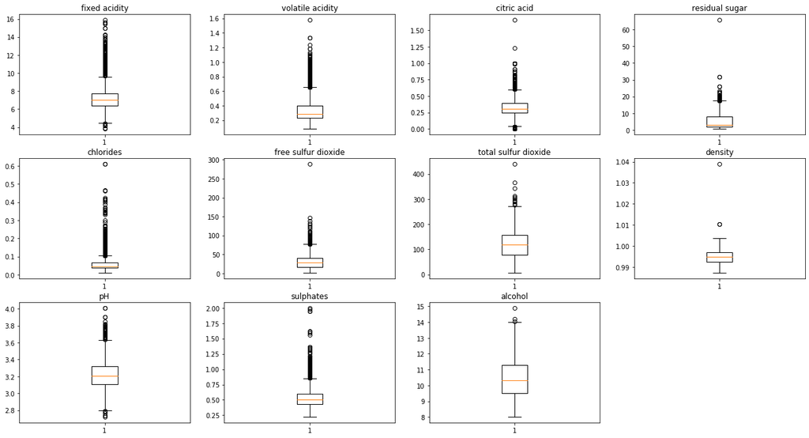

```python
outliers_by_12_variables = ['fixed acidity', 'volatile acidity', 'citric acid',
                            'residual sugar', 'chlorides', 'free sulfur dioxide',
                            'total sulfur dioxide', 'density', 'pH', 'sulphates', 'alcohol']
plt.figure(figsize=(22,20))

for i in range(0,11):
    plt.subplot(5, 4, i+1)
    plt.boxplot(wine_clean[outliers_by_12_variables[i]])
    plt.title(outliers_by_12_variables[i])
```

```python
from scipy import stats

#Function to detect outliers above or below 3 sigma value in the normal distribution
def drop_numerical_outliers(df, z_thresh=3):
    # outliers will contain `True` or `False` depending on if it is a value below the threshold.
    outliers = df.select_dtypes(include=[np.number]) \
        .apply(lambda x: np.abs(stats.zscore(x)) < z_thresh) \
        .all(axis=1)
    # Drop (inplace) values set to be rejected
    df.drop(df.index[~outliers], inplace=True)
    return df
```

```python
wine_out = drop_numerical_outliers(wine_clean)
wine_out = wine_out.reset_index(drop = True)
wine_out
```

|  | type | fixed acidity | volatile acidity | citric acid | residual sugar | chlorides | free sulfur dioxide | total sulfur dioxide | density | pH | sulphates | alcohol | quality |
| --- | --- | --- | --- | --- | --- | --- | --- | --- | --- | --- | --- | --- | --- |
| 0 | white | 6.3 | 0.300 | 0.34 | 1.6 | 0.049 | 14.0 | 132.0 | 0.99400 | 3.30 | 0.49 | 9.5 | 6 |
| 1 | white | 8.1 | 0.280 | 0.40 | 6.9 | 0.050 | 30.0 | 97.0 | 0.99510 | 3.26 | 0.44 | 10.1 | 6 |
| 2 | white | 7.2 | 0.230 | 0.32 | 8.5 | 0.058 | 47.0 | 186.0 | 0.99560 | 3.19 | 0.40 | 9.9 | 6 |
| 3 | white | 7.2 | 0.230 | 0.32 | 8.5 | 0.058 | 47.0 | 186.0 | 0.99560 | 3.19 | 0.40 | 9.9 | 6 |
| 4 | white | 8.1 | 0.280 | 0.40 | 6.9 | 0.050 | 30.0 | 97.0 | 0.99510 | 3.26 | 0.44 | 10.1 | 6 |
| ... | ... | ... | ... | ... | ... | ... | ... | ... | ... | ... | ... | ... | ... |
| 5984 | red | 6.2 | 0.600 | 0.08 | 2.0 | 0.090 | 32.0 | 44.0 | 0.99490 | 3.45 | 0.58 | 10.5 | 5 |
| 5985 | red | 5.9 | 0.550 | 0.10 | 2.2 | 0.062 | 39.0 | 51.0 | 0.99512 | 3.52 | 0.51 | 11.2 | 6 |
| 5986 | red | 6.3 | 0.510 | 0.13 | 2.3 | 0.076 | 29.0 | 40.0 | 0.99574 | 3.42 | 0.75 | 11.0 | 6 |
| 5987 | red | 5.9 | 0.645 | 0.12 | 2.0 | 0.075 | 32.0 | 44.0 | 0.99547 | 3.57 | 0.71 | 10.2 | 5 |
| 5988 | red | 6.0 | 0.310 | 0.47 | 3.6 | 0.067 | 18.0 | 42.0 | 0.99549 | 3.39 | 0.66 | 11.0 | 6 |

5989 rows × 13 columns

```python
wine_out.type.value_counts()
```

```
white    4712
red      1277
Name: type, dtype: int64
```

### Data Exploration

```python
corr_matrix = wine_out.corr()
corr_list = corr_matrix.quality.abs().sort_values(ascending=False).index[0:]
corr_list
```

```
Index(['quality', 'alcohol', 'density', 'chlorides', 'volatile acidity',
       'fixed acidity', 'citric acid', 'free sulfur dioxide', 'sulphates',
       'total sulfur dioxide', 'residual sugar', 'pH'],
      dtype='object')
```

#### Heatmap of correlation between variables

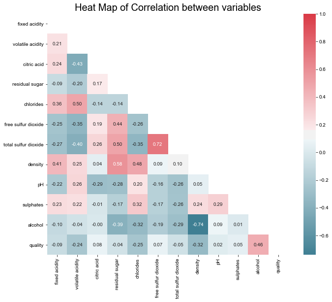

```python
plt.figure(figsize=(11,9))
dropSelf = np.zeros_like(corr_matrix)
dropSelf[np.triu_indices_from(dropSelf)] = True
plt.title("Heat Map of Correlation between variables",fontsize = 20)
sns.heatmap(corr_matrix, cmap=sns.diverging_palette(220, 10, as_cmap=True), annot=True, fmt=".2f", mask=dropSelf)

sns.set(font_scale= 1)
```

While wine Quality has the highest positive correlation with alcohol. Alcohol has negative correlation with density. Alcohol also has a negative correlation with residual sugars. Quality has low correlation with fixed acidity, citric acid, pH, total and free sulfar dioxides

#### Distribution of variables

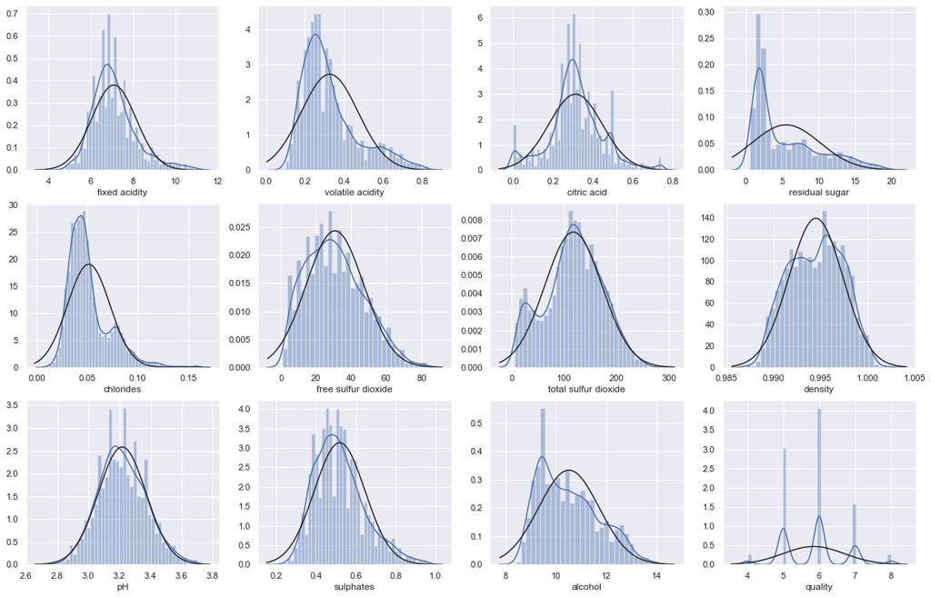

```python
from scipy.stats import norm
plt.figure(figsize = (20,22))

for i in range(1,13):
    plt.subplot(5,4,i)
    sns.distplot(wine_out[wine_out.columns[i]], fit=norm)
```

#### Binning into low and high Quality

```python
wine_bins = wine_out.copy()
bins = [0,5,10]

labels = [0, 1] # 'low'=0, 'high'=1
wine_bins['quality_range']= pd.cut(x=wine_bins['quality'], bins=bins, labels=labels)

print(wine_bins[['quality_range','quality']].head(5))

wine_bins = wine_bins.drop('quality', axis=1)
```

```
  quality_range  quality
0             1        6
1             1        6
2             1        6
3             1        6
4             1        6
```

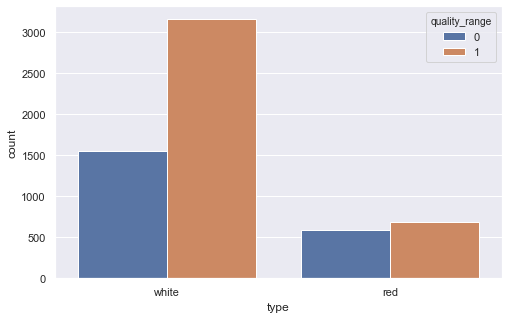

```python
plt.figure(figsize=(8,5))

sns.countplot(x = 'type', hue = 'quality_range', data = wine_bins)
plt.show()
# 'low'=0, 'high'=1
```

#### Data exploration using different plots

##### Violin plots

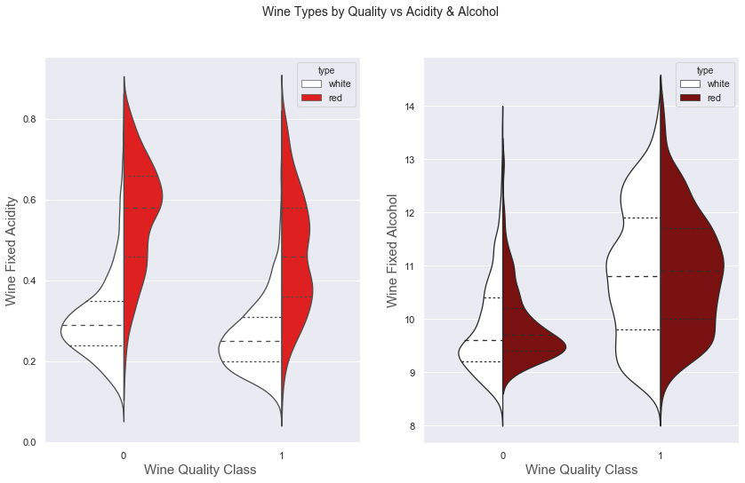

```python
f, (ax1, ax2) = plt.subplots(1, 2, figsize=(14, 8))
f.suptitle('Wine Types by Quality vs Acidity & Alcohol', fontsize=14)

sns.violinplot(x='quality_range', y='volatile acidity', hue='type', data=wine_bins, split=True, inner='quart', linewidth=1.3,
               palette={'red': 'red', 'white': 'white'}, ax=ax1)
ax1.set_xlabel("Wine Quality Class ",size = 15,alpha=0.8)
ax1.set_ylabel("Wine Fixed Acidity",size = 15,alpha=0.8)

sns.violinplot(x='quality_range', y='alcohol', hue='type', data=wine_bins, split=True, inner='quart', linewidth=1.3,
               palette={'red': 'darkred', 'white': 'white'}, ax=ax2)
ax2.set_xlabel("Wine Quality Class",size = 15,alpha=0.8)
ax2.set_ylabel("Wine Fixed Alcohol",size = 15,alpha=0.8)
plt.show()
```

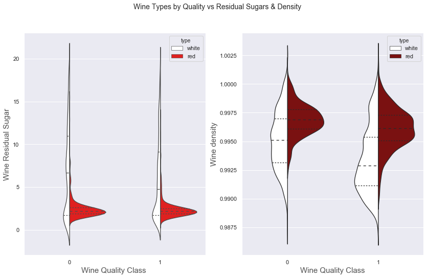

```python
f, (ax1, ax2) = plt.subplots(1, 2, figsize=(14, 8))
f.suptitle('Wine Types by Quality vs Residual Sugars & Density', fontsize=14)

sns.violinplot(x='quality_range', y='residual sugar', hue='type', data=wine_bins, split=True, inner='quart', linewidth=1.3,
               palette={'red': 'red', 'white': 'white'}, ax=ax1)
ax1.set_xlabel("Wine Quality Class ",size = 15,alpha=0.8)
ax1.set_ylabel("Wine Residual Sugar",size = 15,alpha=0.8)

sns.violinplot(x='quality_range', y='density', hue='type', data=wine_bins, split=True, inner='quart', linewidth=1.3,
               palette={'red': 'darkred', 'white': 'white'}, ax=ax2)
ax2.set_xlabel("Wine Quality Class",size = 15,alpha=0.8)
ax2.set_ylabel("Wine density",size = 15,alpha=0.8)
plt.show()
```

##### Histograms

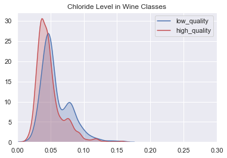

```python
plt.figure(figsize= (6,4))

low_quality = wine_bins [wine_bins['quality_range']== 0]['chlorides']
high_quality   = wine_bins [wine_bins['quality_range']== 1][ 'chlorides']
ax = sns.kdeplot(data= low_quality, label= 'low_quality', shade=True, color=None)
ax = sns.kdeplot(data= high_quality,label= 'high_quality',shade=True, color= "r")

plt.title("Chloride Level in Wine Classes")
plt.xlim(0.0,0.3)
plt.legend()
plt.show()
```

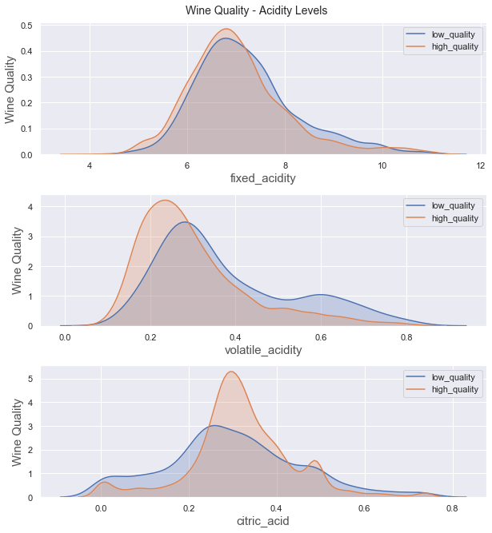

```python
f, (ax1, ax2, ax3) = plt.subplots(3, figsize = (10,10))

f.suptitle('Wine Quality - Acidity Levels', fontsize=14)


fixed_acidity_low_quality    = wine_bins [wine_bins['quality_range']== 0]['fixed acidity']
fixed_acidity_high_quality   = wine_bins [wine_bins['quality_range']== 1]['fixed acidity']


volatile_acidity_low_quality = wine_bins [wine_bins['quality_range']== 0]['volatile acidity']
volatile_acidity_high_quality= wine_bins [wine_bins['quality_range']== 1]['volatile acidity']

citric_acid_low_quality      = wine_bins [wine_bins['quality_range']== 0]['citric acid']
citric_acid_high_quality     = wine_bins [wine_bins['quality_range']== 1]['citric acid']


sns.kdeplot(data=fixed_acidity_low_quality, label="low_quality", shade=True,ax=ax1)
sns.kdeplot(data=fixed_acidity_high_quality, label="high_quality", shade=True, ax=ax1)
ax1.set_xlabel("fixed_acidity",size = 15,alpha=0.8)
ax1.set_ylabel("Wine Quality",size = 15,alpha=0.8)

sns.kdeplot(data=volatile_acidity_low_quality, label="low_quality", shade=True,ax=ax2)
sns.kdeplot(data=volatile_acidity_high_quality, label="high_quality", shade=True, ax=ax2)
ax2.set_xlabel("volatile_acidity",size = 15,alpha=0.8)
ax2.set_ylabel("Wine Quality",size = 15,alpha=0.8)


sns.kdeplot(data=citric_acid_low_quality, label="low_quality", shade=True,ax=ax3)
sns.kdeplot(data=citric_acid_high_quality, label="high_quality", shade=True, ax=ax3)
ax3.set_xlabel("citric_acid",size = 15,alpha=0.8)
ax3.set_ylabel("Wine Quality",size = 15,alpha=0.8)

#Adjust space between sub plots
plt.subplots_adjust(left=None, bottom=None, right=None, top=0.95, wspace=None, hspace=0.3)
# left  = 0.125  # the left side of the subplots of the figure
# right = 0.9    # the right side of the subplots of the figure
# bottom = 0.1   # the bottom of the subplots of the figure
# top = 0.9      # the top of the subplots of the figure
# wspace = 0.2   # the amount of width reserved for blank space between subplots
# hspace = 0.2   # the amount of height reserved for white space between subplots
#Fit subplots automatically
## plt.tight_layout()

plt.legend()
plt.show()
```

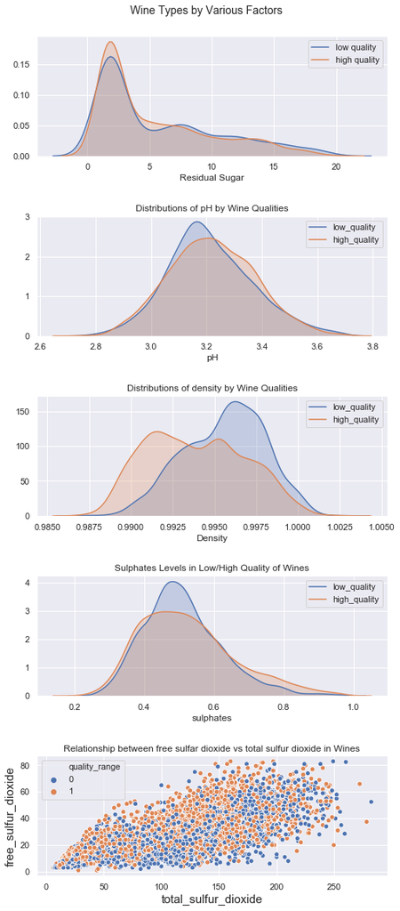

```python
f, (ax1, ax2, ax3, ax4, ax5) = plt.subplots(5, figsize=(8, 18))
f.suptitle('Wine Types by Various Factors', fontsize=14)

residual_sugar_low   = wine_bins [wine_bins['quality_range']== 0]['residual sugar']
residual_sugar_high  = wine_bins [wine_bins['quality_range']== 1]['residual sugar']
ax1 = sns.kdeplot(data= residual_sugar_low, label= 'low quality', shade=True, ax = ax1)
ax1 = sns.kdeplot(data= residual_sugar_high,   label= 'high quality',   shade=True, ax = ax1)
plt.title("Distributions of Residual Sugar by Wine Qualities")
ax1.set_xlabel('Residual Sugar')


pH_low_quality  = wine_bins [wine_bins['quality_range']== 0]['pH']
pH_high_quality = wine_bins [wine_bins['quality_range']== 1][ 'pH']
ax2 = sns.kdeplot(data= pH_low_quality, label= 'low_quality', shade=True, ax = ax2)
ax2 = sns.kdeplot(data= pH_high_quality,label= 'high_quality',   shade=True, ax = ax2)
ax2.set_title("Distributions of pH by Wine Qualities")
ax2.set_xlabel('pH')

density_low_quality  = wine_bins [wine_bins['quality_range']== 0]['density']
density_high_quality = wine_bins [wine_bins['quality_range']== 1][ 'density']
ax3 = sns.kdeplot(data= density_low_quality, label= 'low_quality', shade=True, ax = ax3)
ax3 = sns.kdeplot(data= density_high_quality,label= 'high_quality', shade=True, ax = ax3)
ax3.set_title("Distributions of density by Wine Qualities")
ax3.set_xlabel('Density')


sulphates_low_quality    = wine_bins [wine_bins['quality_range']== 0]['sulphates']
sulphates_high_quality   = wine_bins [wine_bins['quality_range']== 1][ 'sulphates']
ax4 = sns.kdeplot(data= sulphates_low_quality, label= 'low_quality',  shade=True, ax = ax4)
ax4 = sns.kdeplot(data= sulphates_high_quality,label= 'high_quality', shade=True, ax = ax4)
ax4.set_title("Sulphates Levels in Low/High Quality of Wines")
ax4.set_xlabel('sulphates')

ax5.set_title("Relationship between free sulfar dioxide vs total sulfur dioxide in Wines")
ax5 = sns.scatterplot(x='total sulfur dioxide', y='free sulfur dioxide', hue='quality_range',data=wine_bins);
ax5.set_xlabel('total_sulfur_dioxide',size=15)
ax5.set_ylabel('free_sulfur_dioxide', size =15)

plt.legend()
plt.subplots_adjust(left=None, bottom=None, right=None, top=0.95, wspace=None, hspace=0.5)
plt.show()
```

However, in terms of free and total sulfar dioxides, both the quality of wines do not show distinctive differences.

```python
wine_bins.quality_range.value_counts()
```

```
1    3847
0    2142
Name: quality_range, dtype: int64
```

### Class Balancing

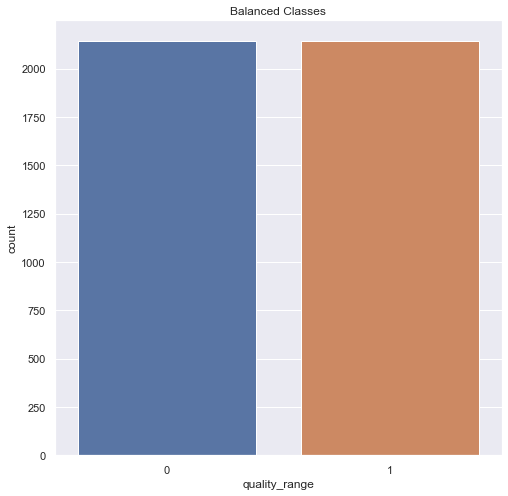

```python
# Shuffle the Dataset.
shuffled_df = wine_bins.sample(frac=1,random_state=4)

# Put all the low quality wine in a separate dataset.
lq_df = shuffled_df.loc[shuffled_df['quality_range'] == 0]

#Randomly select 2142 observations from the high quality wine (majority class)
hq_df = shuffled_df.loc[shuffled_df['quality_range'] == 1].sample(n=2142,random_state=21)

# Concatenate both dataframes again
normalized_df = pd.concat([hq_df, lq_df])

#plot the dataset after the undersampling
plt.figure(figsize=(8, 8))
sns.countplot('quality_range', data=normalized_df)
plt.title('Balanced Classes')
plt.show()
```

### Classification and Prediction

```python
normalized_df.type = normalized_df.type.map({'white':0, 'red':1})
```

```python
from sklearn.model_selection import train_test_split
from sklearn.linear_model import LogisticRegression
from sklearn.metrics import accuracy_score
```

```python
X = normalized_df[['type', 'alcohol', 'density', 'volatile acidity', 'chlorides',
       'citric acid', 'fixed acidity', 'free sulfur dioxide',
       'total sulfur dioxide', 'sulphates', 'residual sugar', 'pH']]
y = normalized_df.quality_range

X_train, X_test, y_train, y_test = train_test_split(X,y, test_size=0.2, random_state=40)
```

### Quick Guide on Classification Metrics

##### Curves

ROC is a probability curve and AUC represents degree or measure of separability. It tells how much model is capable of distinguishing between classes

### Classification Models

#### Function to obtain Confusion matrix & metrics

```python
def make_confusion_matrix(cf,
                          group_names=None,
                          categories='auto',
                          count=True,
                          percent=True,
                          cbar=True,
                          xyticks=True,
                          xyplotlabels=True,
                          sum_stats=True,
                          stats_list = True,
                          figsize=None,
                          cmap='Blues',
                          title=None):
    '''
    This function will make a pretty plot of an sklearn Confusion Matrix cm using a Seaborn heatmap visualization.
    Arguments
    ---------
    cf:            confusion matrix to be passed in
    group_names:   List of strings that represent the labels row by row to be shown in each square.
    categories:    List of strings containing the categories to be displayed on the x,y axis. Default is 'auto'
    count:         If True, show the raw number in the confusion matrix. Default is True.
    normalize:     If True, show the proportions for each category. Default is True.
    cbar:          If True, show the color bar. The cbar values are based off the values in the confusion matrix.
                   Default is True.
    xyticks:       If True, show x and y ticks. Default is True.
    xyplotlabels:  If True, show 'True Label' and 'Predicted Label' on the figure. Default is True.
    sum_stats:     If True, display summary statistics below the figure. Default is True.
    figsize:       Tuple representing the figure size. Default will be the matplotlib rcParams value.
    cmap:          Colormap of the values displayed from matplotlib.pyplot.cm. Default is 'Blues'
                   See http://matplotlib.org/examples/color/colormaps_reference.html

    title:         Title for the heatmap. Default is None.
    '''


    # CODE TO GENERATE TEXT INSIDE EACH SQUARE
    blanks = ['' for i in range(cf.size)]

    if group_names and len(group_names)==cf.size:
        group_labels = ["{}\n".format(value) for value in group_names]
    else:
        group_labels = blanks

    if count:
        group_counts = ["{0:0.0f}\n".format(value) for value in cf.flatten()]
    else:
        group_counts = blanks

    if percent:
        group_percentages = ["{0:.2%}".format(value) for value in cf.flatten()/np.sum(cf)]
    else:
        group_percentages = blanks

    box_labels = [f"{v1}{v2}{v3}".strip() for v1, v2, v3 in zip(group_labels,group_counts,group_percentages)]
    box_labels = np.asarray(box_labels).reshape(cf.shape[0],cf.shape[1])


    # CODE TO GENERATE SUMMARY STATISTICS & TEXT FOR SUMMARY STATS
    if sum_stats:
        #Accuracy is sum of diagonal divided by total observations
        accuracy  = np.trace(cf) / float(np.sum(cf))

        #if it is a binary confusion matrix, show some more stats
        if len(cf)==2:
            #Metrics for Binary Confusion Matrices
            precision = cf[1,1] / sum(cf[:,1])
            recall    = cf[1,1] / sum(cf[1,:])
            f1_score  = 2*precision*recall / (precision + recall)
            stats_text = "\n\nAccuracy={:0.3f}\nPrecision={:0.3f}\nRecall={:0.3f}\nF1 Score={:0.3f}".format(
                accuracy,precision,recall,f1_score)
        else:
            stats_text = "\n\nAccuracy={:0.3f}".format(accuracy)
    else:
        stats_text = ""

    # SET FIGURE PARAMETERS ACCORDING TO OTHER ARGUMENTS
    if figsize==None:
        #Get default figure size if not set
        figsize = plt.rcParams.get('figure.figsize')

    if xyticks==False:
        #Do not show categories if xyticks is False
        categories=False


    # MAKE THE HEATMAP VISUALIZATION
    plt.figure(figsize=figsize)
    sns.heatmap(cf,annot=box_labels,fmt="",cmap=cmap,cbar=cbar,xticklabels=categories,yticklabels=categories)

    if xyplotlabels:
        plt.ylabel('True label')
        plt.xlabel('Predicted label' + stats_text)
    else:
        plt.xlabel(stats_text)

    if title:
        plt.title(title,fontdict = {'fontsize' : 15})

    if stats_list==True:
        #creating a dataframe with classifier and metrics
        make_confusion_matrix.stats_list = pd.DataFrame({'Metrics':['Classifier','Accuracy', 'Precision', 'Recall', 'F1_score'], 'Values':["",accuracy, precision, recall, f1_score]})
```

#### Function to predict, score, create Confusion matrix & ROC curve

```python
def classifier_parametrics(classifier,X_test,y_test):
    '''
    This function will pass a classifier model fit with X_train and y_train data to provide confusion matrix and ROC curve and AUC value.
    Arguments
    ---------
    classifier:    classifer model trained with training data
    X_test:        test data of independent variables
    y_test:        test data of dependent variable

    '''
    # Using the predict function of the classifer to predict the test data values of independent variable(X)
    predictions = classifier.predict(X_test)

    #Obtaining the Accuracy score of the model
    score = round(accuracy_score(y_test, predictions), 3)

    #Creating a confusion matrix
    cm1 = cm(y_test, predictions)

    #Defining the names for the labels in the confusion matrix
    labels = ['True Neg','False Pos','False Neg','True Pos']
    categories = ['Zero', 'One']

    #Using the function make_confusion_matrix to obtain the confusion matrix
    make_confusion_matrix(cm1,
                          group_names=labels,
                          categories=categories, title = "\nConfusion Matrix and Performace Metrics of {} Model".format(re.findall(r'\w+', str(type(classifier)))[-1])
                          )
    #Adding the classifier name to the dataframe
    make_confusion_matrix.stats_list.at[0,'Values'] = re.findall(r'\w+', str(type(classifier)))[-1]

    probs = classifier.predict_proba(X_test)[:,1]  #Predict probabilities for the test data

    fpr, tpr, thresholds  = roc_curve(y_test, probs) #Get the ROC Curve

    plt.figure(figsize=(8,5))
    # Plot ROC curve
    plt.plot([0, 1], [0, 1], 'k--')
    plt.plot(fpr, tpr)
    plt.xlabel('False Positive Rate = 1 - Specificity Score')
    plt.ylabel('True Positive Rate  = Recall Score')
    plt.title('ROC Curve')
    plt.show()
    print('AUC Degree : ', roc_auc_score(y_test.values, probs))

#Defining variable to store metric parameters of different models
model_parameters = pd.DataFrame({'Metrics':['Classifier','Accuracy', 'Precision', 'Recall', 'F1_score']})
```

#### Logistic Regression

```python
lr = LogisticRegression(random_state=40)
lr_model = lr.fit(X_train, y_train)
```

```python
train_accuracy = lr.score(X_train, y_train)
test_accuracy = lr.score(X_test, y_test)
print('One-vs-rest', '-'*35,
      'Accuracy in Train Group   : {:.2f}'.format(train_accuracy),
      'Accuracy in Test  Group   : {:.2f}'.format(test_accuracy), sep='\n')
```

```
One-vs-rest
-----------------------------------
Accuracy in Train Group   : 0.71
Accuracy in Test  Group   : 0.71
```

```python
from sklearn.metrics import confusion_matrix as cm

predictions = lr.predict(X_test)
score = round(accuracy_score(y_test, predictions), 3)
cm1 = cm(y_test, predictions)

#Different colors for heatmap
# sns.heatmap(df, cmap="YlGnBu")
# sns.heatmap(df, cmap="Blues")
# sns.heatmap(df, cmap="BuPu")
# sns.heatmap(df, cmap="Greens")
```

##### Logistic Regression Performance Metrics

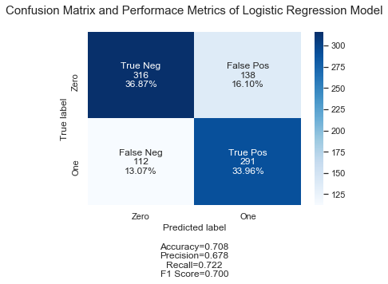

```python
labels = ['True Neg','False Pos','False Neg','True Pos']
categories = ['Zero', 'One']
make_confusion_matrix(cm1,
                      group_names=labels,
                      categories=categories, title = "Confusion Matrix and Performace Metrics of Logistic Regression Model\n"
                      )
```

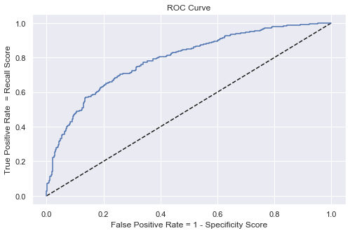

```
AUC Degree :  0.7885079961959314
```

```python
probs = lr_model.predict_proba(X_test)[:,1]  #Predict probabilities for the test data

from sklearn.metrics import roc_curve, roc_auc_score

fpr, tpr, thresholds  = roc_curve(y_test, probs) #Get the ROC Curve

plt.figure(figsize=(8,5))
# Plot ROC curve
plt.plot([0, 1], [0, 1], 'k--')
plt.plot(fpr, tpr)
plt.xlabel('False Positive Rate = 1 - Specificity Score')
plt.ylabel('True Positive Rate  = Recall Score')
plt.title('ROC Curve')
plt.show()
print('AUC Degree : ', roc_auc_score(y_test.values, probs))
```

#### Logistic Regression using functions

```
Accuracy of Decision Tree classifier on training set: 0.71
Accuracy of Decision Tree classifier on test set: 0.71
```

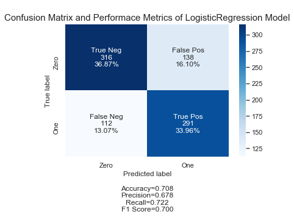

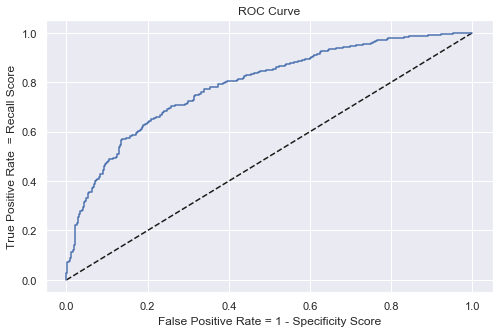

```
AUC Degree :  0.7885079961959314
```

```python
print('Accuracy of Decision Tree classifier on training set: {:.2f}'
     .format(lr_model.score(X_train, y_train)))
print('Accuracy of Decision Tree classifier on test set: {:.2f}'
     .format(lr_model.score(X_test, y_test)))
classifier_parametrics(lr_model,X_test,y_test)
model_parameters['model1'] = make_confusion_matrix.stats_list.Values
```

#### Decision Tree Classifier

```
Accuracy of Decision Tree classifier on training set: 1.00
Accuracy of Decision Tree classifier on test set: 0.73
```

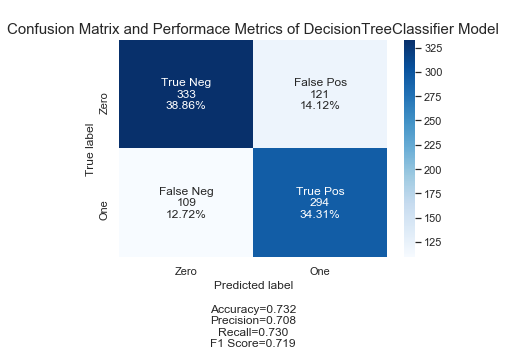

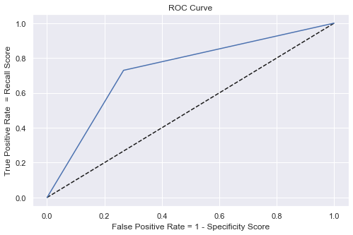

```
AUC Degree :  0.7315043560958013
```

```python
from sklearn.tree import DecisionTreeClassifier
clf = DecisionTreeClassifier().fit(X_train, y_train)

print('Accuracy of Decision Tree classifier on training set: {:.2f}'
     .format(clf.score(X_train, y_train)))
print('Accuracy of Decision Tree classifier on test set: {:.2f}'
     .format(clf.score(X_test, y_test)))

classifier_parametrics(clf,X_test,y_test)
model_parameters['model2'] = make_confusion_matrix.stats_list.Values
```

#### K-Nearest Neighbors

```
Accuracy of K-NN classifier on training set: 0.77
Accuracy of K-NN classifier on test set: 0.63
```

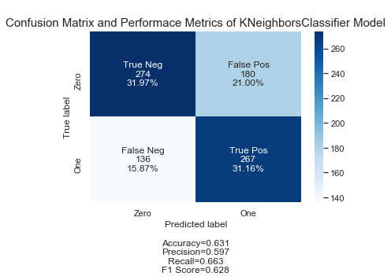

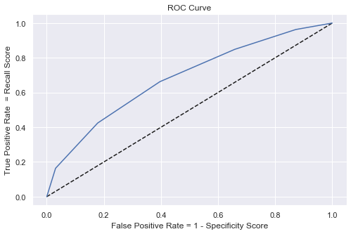

```
AUC Degree :  0.6813545982225818
```

```python
from sklearn.neighbors import KNeighborsClassifier
knn = KNeighborsClassifier()
knn.fit(X_train, y_train)
print('Accuracy of K-NN classifier on training set: {:.2f}'
     .format(knn.score(X_train, y_train)))
print('Accuracy of K-NN classifier on test set: {:.2f}'
     .format(knn.score(X_test, y_test)))

classifier_parametrics(knn,X_test,y_test)
model_parameters['model3'] = make_confusion_matrix.stats_list.Values
```

#### Linear Discriminant Analysis

```
Accuracy of LDA classifier on training set: 0.73
Accuracy of LDA classifier on test set: 0.74
```

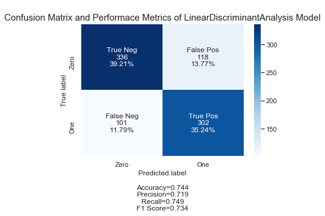

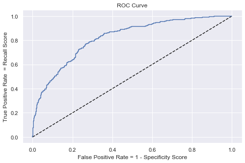

```
AUC Degree :  0.8196784031656847
```

```python
from sklearn.discriminant_analysis import LinearDiscriminantAnalysis
lda = LinearDiscriminantAnalysis()
lda.fit(X_train, y_train)
print('Accuracy of LDA classifier on training set: {:.2f}'
     .format(lda.score(X_train, y_train)))
print('Accuracy of LDA classifier on test set: {:.2f}'
     .format(lda.score(X_test, y_test)))

classifier_parametrics(lda,X_test,y_test)
model_parameters['model4'] = make_confusion_matrix.stats_list.Values
```

#### Gaussian Naive Bayes

```
Accuracy of GNB classifier on training set: 0.69
Accuracy of GNB classifier on test set: 0.70
```

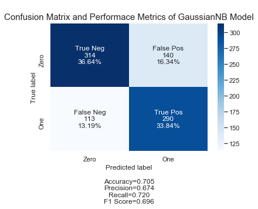

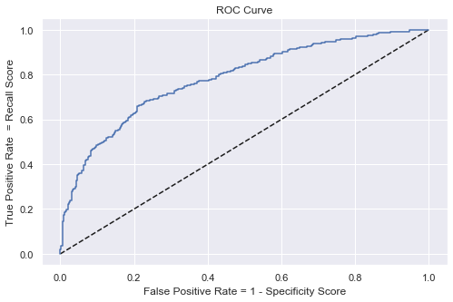

```
AUC Degree :  0.7830041210743214
```

```python
from sklearn.naive_bayes import GaussianNB
gnb = GaussianNB()
gnb.fit(X_train, y_train)
print('Accuracy of GNB classifier on training set: {:.2f}'
     .format(gnb.score(X_train, y_train)))
print('Accuracy of GNB classifier on test set: {:.2f}'
     .format(gnb.score(X_test, y_test)))

classifier_parametrics(gnb,X_test,y_test)
model_parameters['model5'] = make_confusion_matrix.stats_list.Values
```

#### Support Vector Machine

```
Accuracy of SVM classifier on training set: 0.63
Accuracy of SVM classifier on test set: 0.63
```

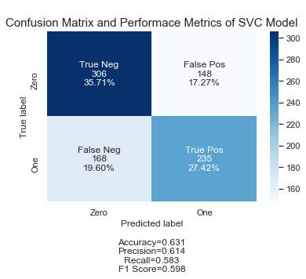

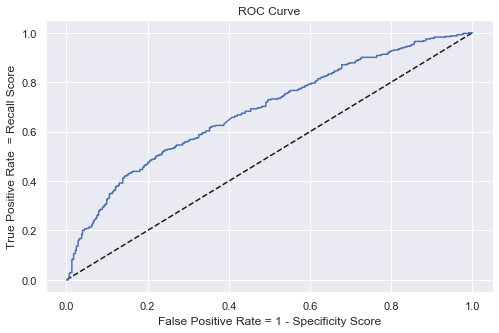

```
AUC Degree :  0.684330626031635
```

```python
from sklearn.svm import SVC
svm = SVC(probability =True)
svm.fit(X_train, y_train)
print('Accuracy of SVM classifier on training set: {:.2f}'
     .format(svm.score(X_train, y_train)))
print('Accuracy of SVM classifier on test set: {:.2f}'
     .format(svm.score(X_test, y_test)))

classifier_parametrics(svm,X_test,y_test)
model_parameters['model6'] = make_confusion_matrix.stats_list.Values
```

#### Random Forest Classifier

```
Accuracy of RF classifier on test set: 0.72
```

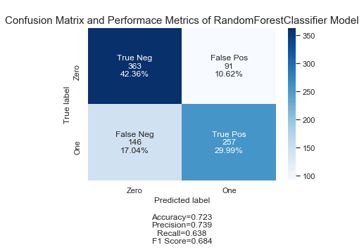

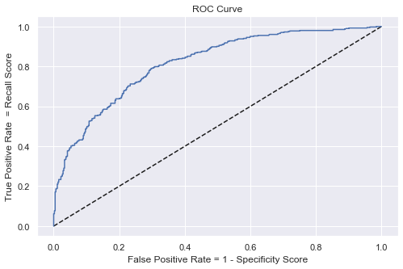

```
AUC Degree :  0.8172188760507647
```

```python
import sklearn as sk
from sklearn.ensemble import RandomForestClassifier

RF = RandomForestClassifier(n_estimators=100, max_depth=2, random_state=0)
RF.fit(X, y)
RF.predict(X.iloc[460:,:])
print('Accuracy of RF classifier on test set: {:.2f}'
     .format(round(RF.score(X,y), 4)))

classifier_parametrics(RF,X_test,y_test)
model_parameters['model7'] = make_confusion_matrix.stats_list.Values
```

#### Gradient Boosting Classifier Model

```
Learning rate:  0.05
Accuracy score (training): 0.711
Accuracy score (validation): 0.706
Learning rate:  0.075
Accuracy score (training): 0.734
Accuracy score (validation): 0.729
Learning rate:  0.1
Accuracy score (training): 0.737
Accuracy score (validation): 0.727
Learning rate:  0.25
Accuracy score (training): 0.762
Accuracy score (validation): 0.743
Learning rate:  0.5
Accuracy score (training): 0.767
Accuracy score (validation): 0.741
Learning rate:  0.75
Accuracy score (training): 0.772
Accuracy score (validation): 0.751
Learning rate:  1
Accuracy score (training): 0.779
Accuracy score (validation): 0.746
```

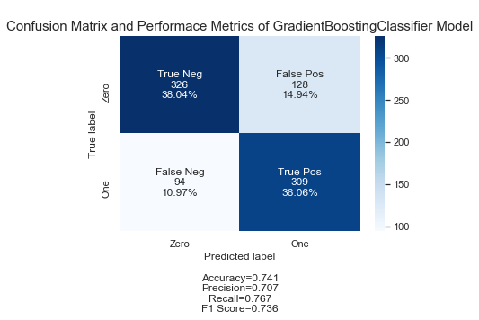

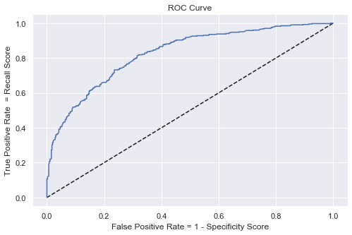

```
AUC Degree :  0.8260923033198151
```

```python
from sklearn.ensemble import GradientBoostingClassifier

lr_list = [0.05, 0.075, 0.1, 0.25, 0.5, 0.75, 1]

for learning_rate in lr_list:
    gb_clf = GradientBoostingClassifier(n_estimators=20, learning_rate=learning_rate, max_features=2, max_depth=2, random_state=0)
    gb_clf.fit(X_train, y_train)

    print("Learning rate: ", learning_rate)
    print("Accuracy score (training): {0:.3f}".format(gb_clf.score(X_train, y_train)))
    print("Accuracy score (validation): {0:.3f}".format(gb_clf.score(X_test, y_test)))

gb_clf2 = GradientBoostingClassifier(n_estimators=20, learning_rate=0.5, max_features=2, max_depth=2, random_state=0)
gb_fit = gb_clf2.fit(X_train, y_train)

classifier_parametrics(gb_fit,X_test,y_test)
model_parameters['model8'] = make_confusion_matrix.stats_list.Values
```

### Comparison of different classifiers

```python
#Replacing column names with classifier names
transpose_model_parameters = model_parameters.transpose().reset_index().drop('index', axis = 1)
new_parameters = transpose_model_parameters.rename(columns=transpose_model_parameters.iloc[0]).drop(model_parameters.index[0])
new_parameters
```

|  | Classifier | Accuracy | Precision | Recall | F1_score |
| --- | --- | --- | --- | --- | --- |
| 1 | LogisticRegression | 0.708285 | 0.678322 | 0.722084 | 0.699519 |
| 2 | DecisionTreeClassifier | 0.731622 | 0.708434 | 0.729529 | 0.718826 |
| 3 | KNeighborsClassifier | 0.631272 | 0.597315 | 0.662531 | 0.628235 |
| 4 | LinearDiscriminantAnalysis | 0.744457 | 0.719048 | 0.74938 | 0.7339 |
| 5 | GaussianNB | 0.704784 | 0.674419 | 0.719603 | 0.696279 |
| 6 | SVC | 0.631272 | 0.613577 | 0.583127 | 0.597964 |
| 7 | RandomForestClassifier | 0.723454 | 0.738506 | 0.637717 | 0.684421 |
| 8 | GradientBoostingClassifier | 0.740957 | 0.707094 | 0.766749 | 0.735714 |

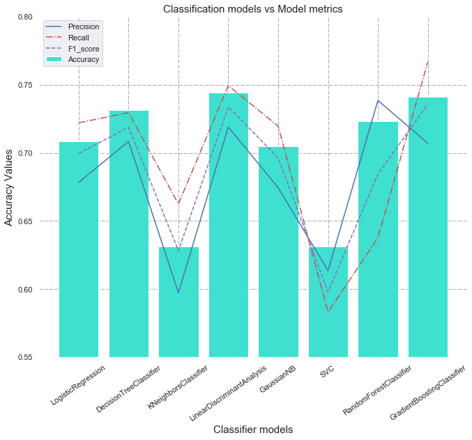

```python
fig = plt.figure(figsize = (11, 9))
plt.bar(new_parameters.Classifier,new_parameters.Accuracy, color ='turquoise', label = 'Accuracy')
plt.plot(new_parameters.Classifier,new_parameters.Precision, color ='b', label = 'Precision')
plt.plot(new_parameters.Classifier,new_parameters.Recall, color ='r',linestyle = "-.", label = 'Recall')
plt.plot(new_parameters.Classifier,new_parameters.F1_score, color ='m',linestyle = "--", label = 'F1_score')

plt.xticks(rotation= 35)
plt.ylim(0.55, 0.8)

ax = plt.axes()
# Setting the background color
ax.set_facecolor("white")

plt.grid(color='grey', linestyle='-.', linewidth=0.7)
plt.xlabel("Classifier models",fontsize = 15)
plt.ylabel("Accuracy Values",fontsize = 15)
plt.title("Classification models vs Model metrics", fontsize = 15)
plt.legend()
plt.show()
```

From the above plot, we see that Linear Discriminant Analysis classifier and Gradient boosting Classifier have better accuracy, precision, recall and f1-score than most models. Chossing the best model depends upon the objective. If the business objective is focussed on High Quality, then we use the classifier with high precision. If the objective is focussed on having low number of low quality wines in a given sample then we use the model with high Recall. Among all the classifiers, the one with high precision is the Random Forest Classifier model and one with high recall is Gradient boosting Classifier model. If the objective aims at high precision and recall i.e. correctly classifying both high quality and low quality wines, then Linear Discriminant Analysis model or Gradient boosting Classifier model can be used.

### References

1. https://www.kaggle.com/ecedolen/classification-logistic-regression-wine-quality
2. https://medium.com/@dtuk81/confusion-matrix-visualization-fc31e3f30fea
3. https://github.com/DTrimarchi10/confusion_matrix
4. https://matplotlib.org/3.1.0/gallery/color/named_colors.html

### Source

1. Data - https://archive.ics.uci.edu/ml/datasets/wine+quality
2. make_confusion_matrix() function - https://github.com/DTrimarchi10/confusion_matrix/blob/master/cf_matrix.py